# Coursera Developing Data Products: Course Project

Hassan

August 16, 2018

## ‘Introduction’

This presentation is created as part of the requirement for the Coursera Developing Data Products Course. Objectives of the assignment are to understanding the essential concepts such as :

- shiny to build data product application and reactive output .
- R-Presentation or slidify to create data product related presentations .

## ‘The Application’

An application based on the “salary” dataset from [R] has been developed and deployed at : https://hbarar.shinyapps.io/Salaries/ . The app allows to perform interactive data analysis from a set of user specified criterias . Therfore User will be able to further refine the results by choosing the influential parameters as below:

- Gender
- Rank
- Years since getting PhD
- Years of experience range

The source codes for ui.R and server.R files are also available on the GitHub repo

## “Data”

```r
data <- read.csv("Salary.csv", sep=",", header=T)
head(data[2:7],4)
```

```
##       rank discipline yrs.since.phd yrs.service  sex salary
## 1     Prof          B            19          18 Male 139750
## 2     Prof          B            20          16 Male 173200
## 3 AsstProf          B             4           3 Male  79750
## 4     Prof          B            45          39 Male 115000
```

Question : What would be the estimation salary for persons who :

- Are male
- Professors
- years since PhD : 5 years
- service : 15 to 20 years

-Note: Through shiny app you can change the above settings and as a result , the table, histogram and output would coordinate and change subsequently

## Result

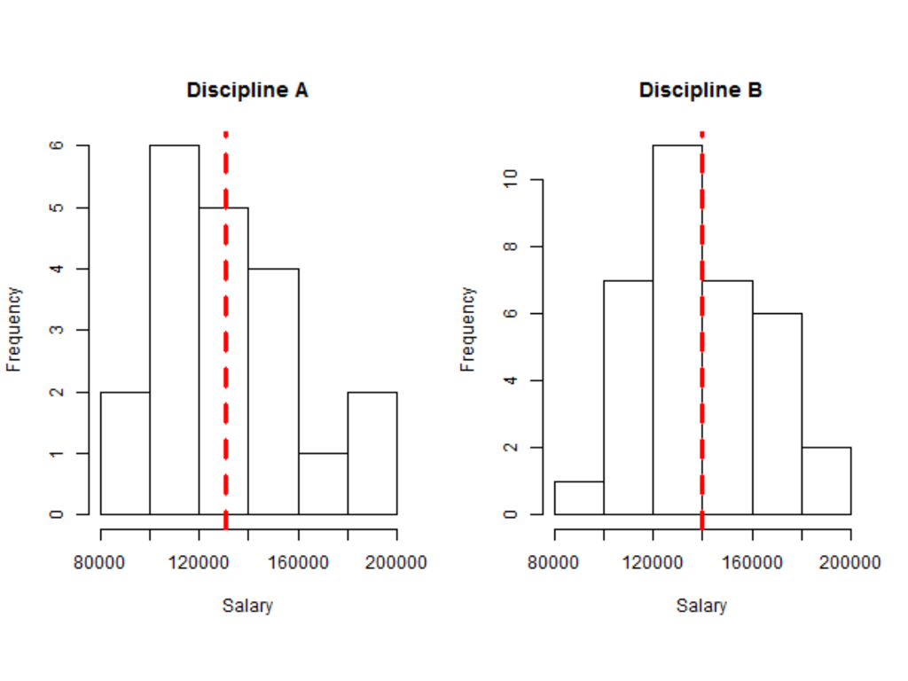

```r
 library(png)
img<-readPNG('C:\\Users\\hassan\\Desktop\\Data-Product -Project\\Salaries\\image.png')
 grid::grid.raster(img)
```